# Breast Mass Classification

Jade O’Brien

# Introduction

The goal of this project is to use machine learning techniques to classify whether a breast mass is malignant (cancerous) or benign (harmless).

## How do we go about doing this?

When doctors are trying to determine whether a breast mass is malignant or benign, they may perform a biopsy, which is a procedure to obtain a sample of cells or tissue from the mass to be used in further testing. One such biopsy technique is known as fine needle aspiration (FNA) which involves using a thin needle and syringe to collect cells from the breast mass, which are then sent to a lab for imaging and analysis. FNA is the least invasive type of biopsy.

[figure not shown]

Our dataset ([provided by the UCI machine learning repository](https://www.kaggle.com/datasets/uciml/breast-cancer-wisconsin-data/data)) includes measurements of the nuclei of the cells obtained through FNA on different breast masses, as well as whether or not the respective mass was benign or malignant. In particular, the sample of cells collected from each mass were imaged, then measurements of the nucleus (such as radius, concavity, symmetry, and texture) were recorded for each cell in the sample. The average, standard error, and worst value of each measurement of the sample were then included in the dataset. We aim to create a model that will use the cell nucleus measurements to predict whether its corresponding mass is malignant or benign.

# Exploratory Data Analysis (EDA)

We’ll load in our data and the packages that we will be using throughout this project.

```r
library(readr)
library(kernlab)
library(tidyverse)
library(tidymodels)
library(ggplot2)
library(corrplot)
library(ggthemes)
library(forcats)
library(kableExtra)
library(corrr)
library(naniar)
library(discrim)
library(RColorBrewer)
library(dendextend)
library(cluster)
library(gplots)
library(NbClust)
library(ranger)
library(vip)
library(xgboost)
library(cluster)
tidymodels_prefer()

bcdata <- read_csv("data.csv")
```

Next, let’s take a quick look at what our dataset looks like, and get some information about the included variables.

```r
bcdata %>%
  summary()
```

```
##        id             diagnosis          radius_mean      texture_mean
##  Min.   :     8670   Length:568         Min.   : 6.981   Min.   : 9.71
##  1st Qu.:   869222   Class :character   1st Qu.:11.707   1st Qu.:16.17
##  Median :   906157   Mode  :character   Median :13.375   Median :18.84
##  Mean   : 30425140                      Mean   :14.139   Mean   :19.28
##  3rd Qu.:  8825022                      3rd Qu.:15.797   3rd Qu.:21.79
##  Max.   :911320502                      Max.   :28.110   Max.   :39.28
##  perimeter_mean     area_mean      smoothness_mean   compactness_mean
##  Min.   : 43.79   Min.   : 143.5   Min.   :0.06251   Min.   :0.01938
##  1st Qu.: 75.20   1st Qu.: 420.3   1st Qu.:0.08640   1st Qu.:0.06517
##  Median : 86.29   Median : 551.4   Median :0.09589   Median :0.09312
##  Mean   : 92.05   Mean   : 655.7   Mean   :0.09644   Mean   :0.10445
##  3rd Qu.:104.15   3rd Qu.: 784.1   3rd Qu.:0.10533   3rd Qu.:0.13043
##  Max.   :188.50   Max.   :2501.0   Max.   :0.16340   Max.   :0.34540
##  concavity_mean    concave points_mean symmetry_mean    fractal_dimension_mean
##  Min.   :0.00000   Min.   :0.00000     Min.   :0.1060   Min.   :0.04996
##  1st Qu.:0.02958   1st Qu.:0.02035     1st Qu.:0.1620   1st Qu.:0.05770
##  Median :0.06155   Median :0.03360     Median :0.1792   Median :0.06155
##  Mean   :0.08896   Mean   :0.04901     Mean   :0.1812   Mean   :0.06280
##  3rd Qu.:0.13100   3rd Qu.:0.07401     3rd Qu.:0.1957   3rd Qu.:0.06613
##  Max.   :0.42680   Max.   :0.20120     Max.   :0.3040   Max.   :0.09744
##    radius_se        texture_se      perimeter_se       area_se
##  Min.   :0.1115   Min.   :0.3602   Min.   : 0.757   Min.   :  6.802
##  1st Qu.:0.2324   1st Qu.:0.8331   1st Qu.: 1.605   1st Qu.: 17.850
##  Median :0.3240   Median :1.1080   Median : 2.285   Median : 24.565
##  Mean   :0.4052   Mean   :1.2165   Mean   : 2.867   Mean   : 40.374
##  3rd Qu.:0.4798   3rd Qu.:1.4743   3rd Qu.: 3.360   3rd Qu.: 45.237
##  Max.   :2.8730   Max.   :4.8850   Max.   :21.980   Max.   :542.200
##  smoothness_se      compactness_se      concavity_se     concave points_se
##  Min.   :0.001713   Min.   :0.002252   Min.   :0.00000   Min.   :0.000000
##  1st Qu.:0.005166   1st Qu.:0.013133   1st Qu.:0.01510   1st Qu.:0.007663
##  Median :0.006374   Median :0.020460   Median :0.02592   Median :0.010950
##  Mean   :0.007041   Mean   :0.025515   Mean   :0.03195   Mean   :0.011817
##  3rd Qu.:0.008151   3rd Qu.:0.032455   3rd Qu.:0.04212   3rd Qu.:0.014730
##  Max.   :0.031130   Max.   :0.135400   Max.   :0.39600   Max.   :0.052790
##   symmetry_se       fractal_dimension_se  radius_worst   texture_worst
##  Min.   :0.007882   Min.   :0.0008948    Min.   : 7.93   Min.   :12.02
##  1st Qu.:0.015128   1st Qu.:0.0022445    1st Qu.:13.03   1st Qu.:21.07
##  Median :0.018725   Median :0.0031955    Median :14.97   Median :25.41
##  Mean   :0.020531   Mean   :0.0037967    Mean   :16.28   Mean   :25.67
```

[output cut: 8 more lines]

```
##  Max.   :251.20   Max.   :4254.0   Max.   :0.22260   Max.   :1.05800
##  concavity_worst  concave points_worst symmetry_worst   fractal_dimension_worst
##  Min.   :0.0000   Min.   :0.00000      Min.   :0.1565   Min.   :0.05504
##  1st Qu.:0.1159   1st Qu.:0.06497      1st Qu.:0.2504   1st Qu.:0.07147
##  Median :0.2275   Median :0.10002      Median :0.2821   Median :0.08005
##  Mean   :0.2727   Mean   :0.11481      Mean   :0.2901   Mean   :0.08397
##  3rd Qu.:0.3835   3rd Qu.:0.16168      3rd Qu.:0.3180   3rd Qu.:0.09208
##  Max.   :1.2520   Max.   :0.29100      Max.   :0.6638   Max.   :0.20750
##   ...33
##  Mode:logical
##  NA's:568
##
##
##
##
```

## Diagnosis Distribution

We are interested in seeing how the diagnosis variable is distributed. What is the proportion of malignant to benign entries?

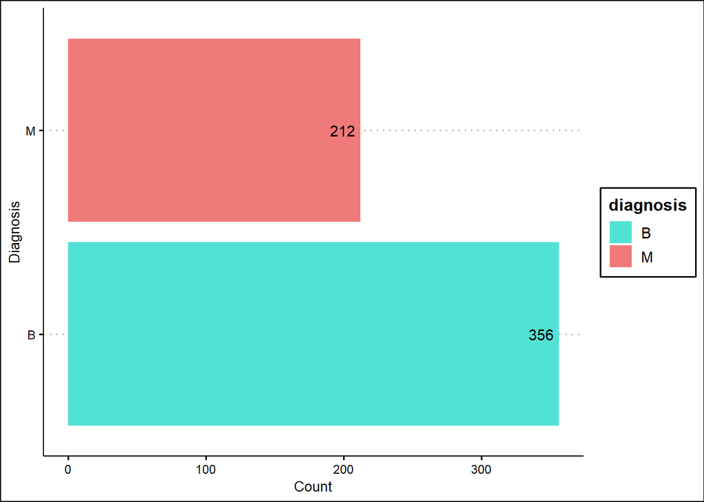

```r
cbPalette <- c("#52E2D5", "#F07979")
bcdata %>%
  ggplot(aes(y=diagnosis, fill=diagnosis)) +
  geom_bar() +
  geom_text(stat = 'count', aes(label= after_stat(count)), hjust = 1.2, color = 'black') +
  labs(y="Diagnosis", x="Count") +
  scale_fill_manual(values=cbPalette) +
  theme_clean()
```

The above bar chart shows us that the diagnosis variable is unbalanced, as there are more benign entries than malignant ones. This is important note as it emphasizes the importance of stratifying on our response variable when we do our training and testing splits. While there is a noticeable disparity, since the ratio of benign to malignant is only about 3:2, this unbalance should not affect us too much, and we won’t be doing anything in particular to account for it other than stratifying on the diagnosis variable when we create our splits.

This discrepancy is generally even more pronounced, as over 80% of breast masses turn out to be benign.

## Variable Correlation

Now let’s see how the predictors are correlated.

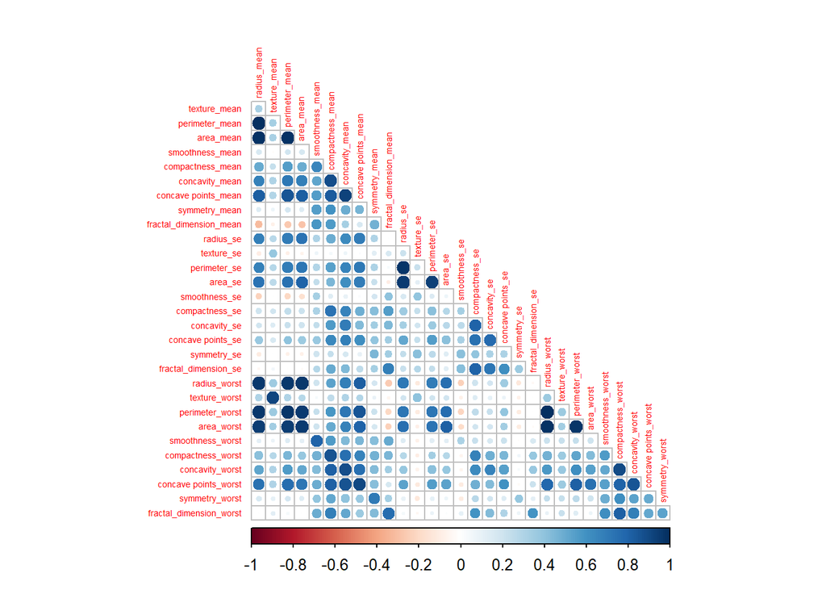

```r
bcdata %>%
  select(is.numeric, -id, -...33) %>%
  cor() %>%
  corrplot(type = 'lower', diag = F, tl.cex = 0.45)
```

Unfortunately, since there are so many predictors, and since they aren’t arranged in any particular order, it’s hard to see exactly what is going on in this plot. So we shall use a clustering technique known as k-medoids to rearrange the order of our predictors into highly correlated groups. However, a cursory glance shows us that for any given feature, its measure of mean and worst are nearly perfectly correlated, so in our next plot we shall leave out the worst measures for each feature.

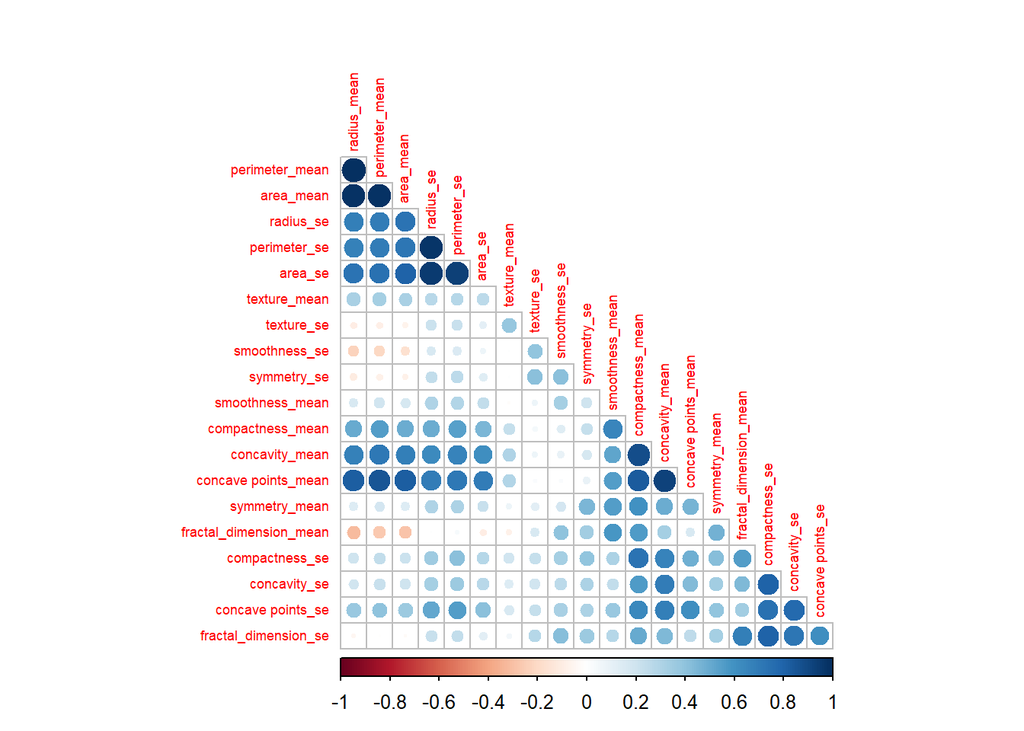

```r
bc_cor <- bcdata %>%
  select(is.numeric, -id, -...33, -contains("worst")) %>%
  cor()

bc_dist <- as.dist(1- bc_cor)

bc_kmedoids <- pam(bc_dist, 4) # create k-medoids

bc_kclusters <- bc_kmedoids$cluster

bc_kmedoids_cor <- bc_cor[order(bc_kclusters), order(bc_kclusters)]

bc_kmedoids_cor %>% corrplot(type = 'lower', diag = F, tl.cex = 0.55, method = 'circle')
```

Much better! It is clear to see that the radius, perimeter, and area features are nearly perfectly correlated, which makes sense as they are all measuring the same phenomena, namely the size of the cell nucleus. We also see concave_points_mean has a high correlation with radius_mean, compactness_mean, and concavity_mean.

## Important Predictors

Next we want to try and figure out what features will be the most useful in predicting whether a mass is malignant or benign.

### Mean Radius

Intuitively, it would make sense that larger cells within breast masses are more associated with malignant tumors, so we aim to see if this intuition is correct.

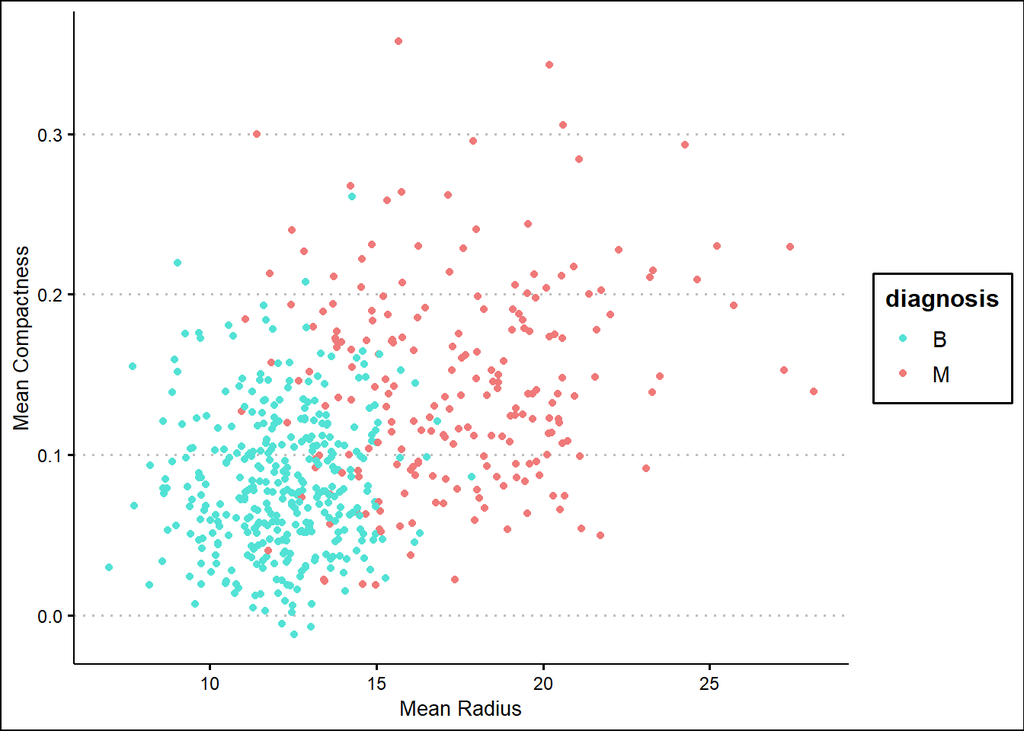

```r
bcdata %>%
  ggplot(aes(radius_mean, compactness_mean, color=diagnosis)) +
  geom_jitter(height = 0.05) +
  scale_colour_manual(values=cbPalette) +
  labs(y= "Mean Compactness", x = "Mean Radius") +
  theme_clean()
```

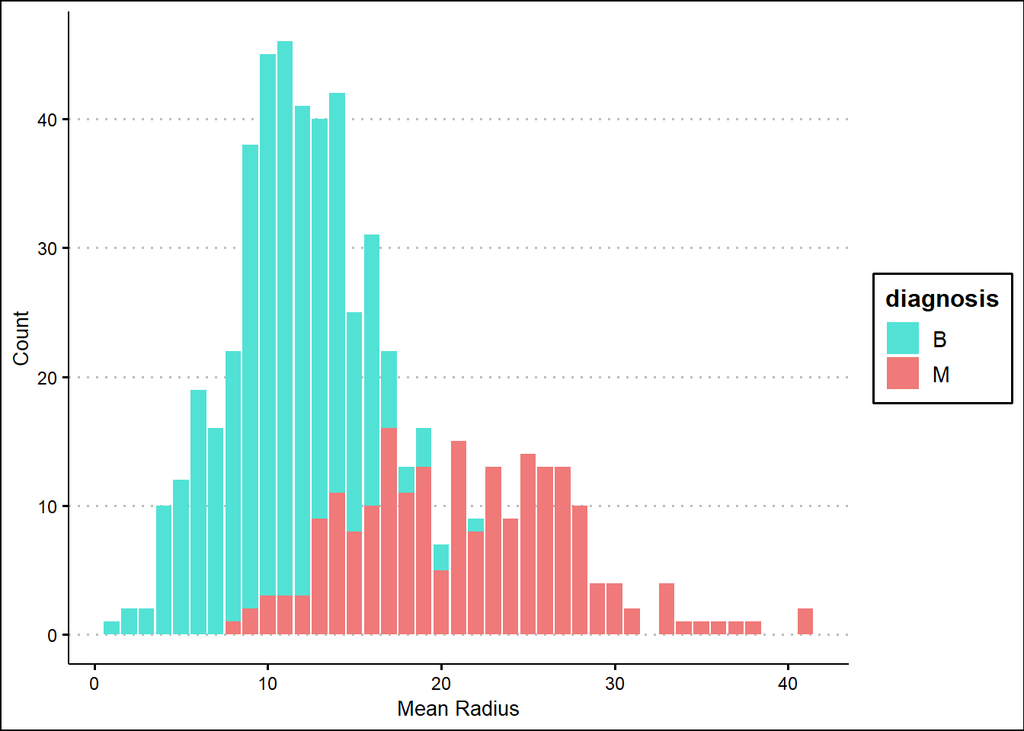

```r
bcdata %>%
  mutate(radius_mean = cut(radius_mean, breaks =
                             seq(min(radius_mean), max(radius_mean), by = .5),
                           include.lowest = TRUE, labels=FALSE)) %>%
  group_by(radius_mean) %>%
  ggplot(aes(radius_mean)) +
  geom_bar(aes(fill=diagnosis)) +
  scale_fill_manual(values=cbPalette) +
  labs(y="Count", x="Mean Radius") +
  theme_clean()
```

Additionally, the scatter plot shows us the correlation between Mean Radius and Mean Compactness that was discussed earlier, with higher values of Mean Radius being correlated with higher values of Mean Compactness.

### Mean Texture and Smoothness Standard Error

The next two features we shall be taking a look at are Mean Texture and Smoothness Standard Error.

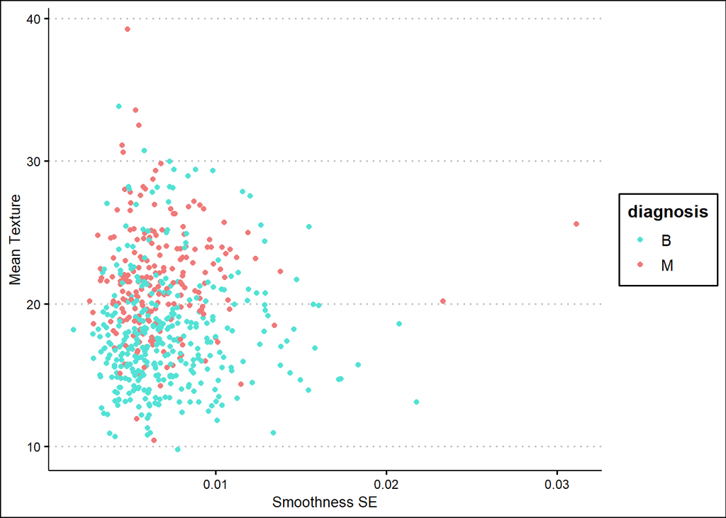

```r
bcdata %>%
  ggplot(aes(smoothness_se, texture_mean, color=diagnosis)) +
  geom_jitter(height = 0.05) +
  scale_colour_manual(values=cbPalette) +
  labs(y = "Mean Texture", x = "Smoothness SE") +
  theme_clean()
```

Unfortunately, the scatter plot shows that neither of these predictors are as useful as Mean Radius. However, we do still see that larger values of Mean Texture are more often associated with malignant growths, and that values of Smoothness SE from 0.01 to 0.02 are usually associated with benign growths.

# Modeling

## Preparing for Model Building

Finally we will move on to the actual modeling part of the project.

The first step is to create our training and testing splits, as well as our folds for cross-validation. What this does is essentially partition our data into 6 disjoint sets. Namely the testing set, and 5 training sets. We use the training sets to create our models, and the testing set is reserved as a set of data that none of our models have seen before, so that we can use it to get a more accurate prediction of model performance. We’ve split 80% of our data into the training sets and 20% of our data into the testing set in order to ensure that we have sufficient data both for training and for accurate model assessment.

The process of creating the 5 folds of the training set is known as k-fold cross-validation (in this case k=5). When we are training our models, the first of the five training folds will be left out of the model training, and only the data from the 4 remaining training folds will be used in training the model. The model will then be used to predict the diagnosis of the data from the first fold that was left out, acting as a sort of pseudo testing set. This process is then repeated 4 more times, each time with a different one of the folds being withheld from model training to be used as a mock test set. This serves two main purposes: it allows us to tune the hyperparameters of different models (more on this later) and it gives us an idea of how each model will perform on the testing set.

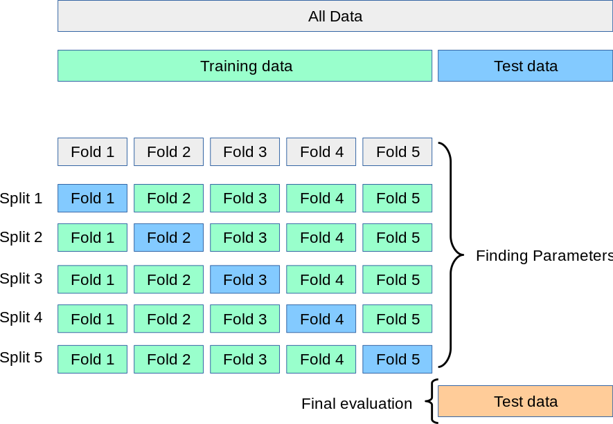

```r
# seed for reproducibility
set.seed(3435)

bc_split <- initial_split(bcdata, prop = 0.8, strata = diagnosis)

bc_train <- training(bc_split)
bc_test <- testing(bc_split)

# seed for reproducibility
set.seed(3435)

bc_folds <- vfold_cv(bc_train, v=5, strata = diagnosis)
```

If you look at the above code chunk you will see that we specified strata = diagnosis when creating our training and testing splits, as well as in the creation of our splits for k-fold cross-validation. This is known as stratifying on the response variable and it ensures that equal proportions of malignant and benign entries will be in each split.

Next we will create the recipe for our models. The recipe is basically an instruction manual for the models we are going to train. It tells the models which variables are predictors, which variable is the response, and if anything special needs to be done to the predictors. In our case we’ve specified that our response variable is diagnosis, and I’ve decided to include all of the other variables as predictors for simplicity and to ensure that no valuable information is lost. Additionally, we will be centering and scaling all of our predictors.

Note that none of the features in the dataset are categorical, so we do not need to dummy code them.

```r
bc_recipe <- recipe(diagnosis ~ ., data = bc_train) %>%
  step_rm(id) %>%
  step_rm(...33) %>%
  step_center(all_predictors())%>%
  step_scale(all_predictors())
```

## Model Creation

Now we will move on to tune and fit our models. We shall be trying out five different models on our dataset, namely KNN, an elastic net, a random forest, gradient boosted trees, and support vector machine. Each of these models has a corresponding set of hyperparameters, or values that need to be specified before training the model, such as the value of k in K-Nearest Neighbors. As was mentioned earlier, k-fold cross-validation gives us a way (called tuning) to test different values of these hyperparameters to determine which one works best.

The process for tuning each of these models is very similar so I will briefly outline what this like below.

- Specify the models you are going to be using, along with what hyperparameters you will be tuning

  ```r
  # KNN
  knn_mod <- nearest_neighbor(neighbors = tune()) %>%
    set_mode("classification") %>%
    set_engine("kknn")

  # Elastic Net
  enet_mod <- logistic_reg(penalty = tune(), mixture = tune()) %>%
    set_mode("classification") %>%
    set_engine("glmnet")

  # Random Forest
  rf_mod <- rand_forest(mtry = tune(),
                             trees = tune(),
                             min_n = tune()) %>%
    set_engine("ranger", num.threads=4) %>%
    set_mode("classification")


  # Gradient Boosted Tree
  bt_mod <- boost_tree(mtry = tune(),
                       trees = tune(),
                       learn_rate = tune()) %>%
    set_engine("xgboost") %>%
    set_mode("classification")

  # SVM
  svm_rbf_spec <- svm_rbf(cost = tune()) %>%
    set_mode("classification") %>%
    set_engine("kernlab")
  ```

- Create a workflow for each model

  ```r
  # KNN
  knn_wkflow <- workflow() %>%
    add_model(knn_mod) %>%
    add_recipe(bc_recipe)

  # Elastic Net
  enet_wkflow <- workflow() %>%
    add_model(enet_mod) %>%
    add_recipe(bc_recipe)

  # Random Forest
  rf_wf <- workflow() %>%
    add_model(rf_mod) %>%
    add_recipe(bc_recipe)

  # Gradient Boosted Tree
  bt_wkflow <- workflow() %>%
    add_model(bt_mod) %>%
    add_recipe(bc_recipe)


  # SVM
  svm_rbf_wkflow <- workflow() %>%
    add_recipe(bc_recipe) %>%
    add_model(svm_rbf_spec)
  ```

- Create a grid for each model that contains the range of values and the number of levels to consider for each hyperparameter

  ```r
  # KNN
  neighbors_grid <- grid_regular(neighbors(range = c(1, 20)), levels = 20)

  # Elastic Net
  enet_grid <- grid_regular(penalty(range = c(0,.5), trans = identity_trans()),
                           mixture(range = c(0,.5)), levels = 10)

  # Random Forest
  rf_grid <- grid_regular(mtry(range = c(1, 20)),
                          trees(range = c(200, 600)),
                          min_n(range = c(1, 10)),
                          levels = 5)

  # Gradient Boosted Tree
  bt_grid <- grid_regular(mtry(range = c(10, 30)),
                          trees(range = c(400, 800)),
                          learn_rate(range = c(-1, 0)),
                          levels = 5)

  # SVM
  svm_rbf_grid <- grid_regular(cost(), levels = 5)
  ```

- Tune each model

  ```r
  # KNN
  knn_tune_res <- tune_grid(
    object = knn_wkflow,
    resamples = bc_folds,
    grid = neighbors_grid,
    control = control_grid(verbose=TRUE)
  )
  save(knn_tune_res, file="knn_tune_res.rda")

  # Elastic Net
  enet_tune_res <- tune_grid(
    object = enet_wkflow,
    resamples = bc_folds,
    grid = enet_grid,
    control = control_grid(verbose=TRUE)
  )
  save(enet_tune_res, file="enet_tune_res.rda")

  # Random Forest
  rf_tune <- tune_grid(
    rf_wf,
    resamples = bc_folds,
    grid = rf_grid,
    control= control_grid(verbose=TRUE)
  )
  save(rf_tune, file="rf_tune.rda")

  # Gradient Boosted Tree
  bt_tune <- tune_grid(
    bt_wkflow,
    resamples = bc_folds,
    grid = bt_grid,
    control= control_grid(verbose=TRUE)
  )
  save(bt_tune, file="bt_tune.rda")

  # SVM
  svm_rbf_res <- tune_grid(svm_rbf_wkflow,
                              bc_folds, svm_rbf_grid, control=control_grid(verbose=TRUE))

  save(svm_rbf_res, file="svm_rbf_res.rda")
  ```

## Model Evaluation

```r
load("knn_tune_res.rda")
load("enet_tune_res.rda")
load("rf_tune.rda")
load("bt_tune.rda")
load("svm_rbf_res.rda")
```

Now we will move on to see how our models performed, and which value of their hyperparameters seemed to work the best. We are going to be using the area under the ROC curve (ROC AUC) as a metric for evaluating the performance of a model. ROC AUC can range from 0.5 to 1, with values closer to one indicating a better model. This metric is generally considered better than using accuracy, as it is able to more easily deal with unbalanced data.

### KNN

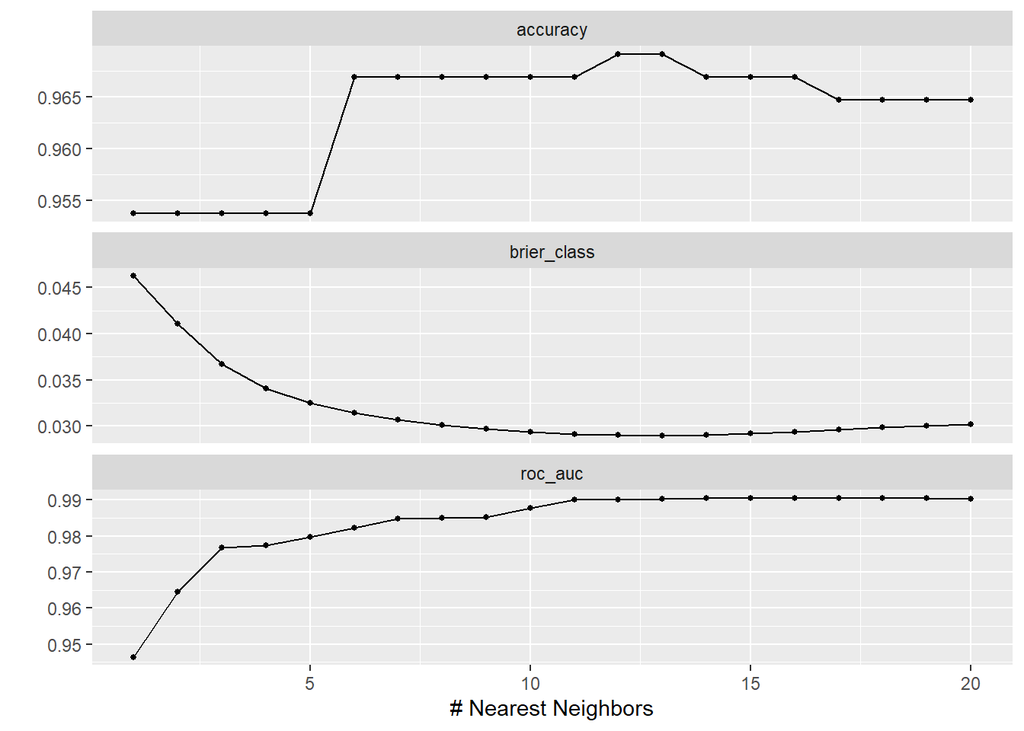

```r
autoplot(knn_tune_res)
```

```r
performance_metrics <- tibble(Model = "KNN", AUC = as.double(show_best(knn_tune_res)[1,4]))
```

KNN is a data-driven model that (in a classification setting) predicts the class of a point by looking at the k closest known data points in feature space, and assigning the mode class of those points. KNN has a hyperparameter known either as k or neighbors, which is the number of closest points that the model will consider when making a prediction. From the graphs above, we can see that a higher value of neighbors performed better in our case. The model with the highest AUC, was the one with neighbors set to 14, which had an AUC of 0.9905 which is really good!

### Elastic Net

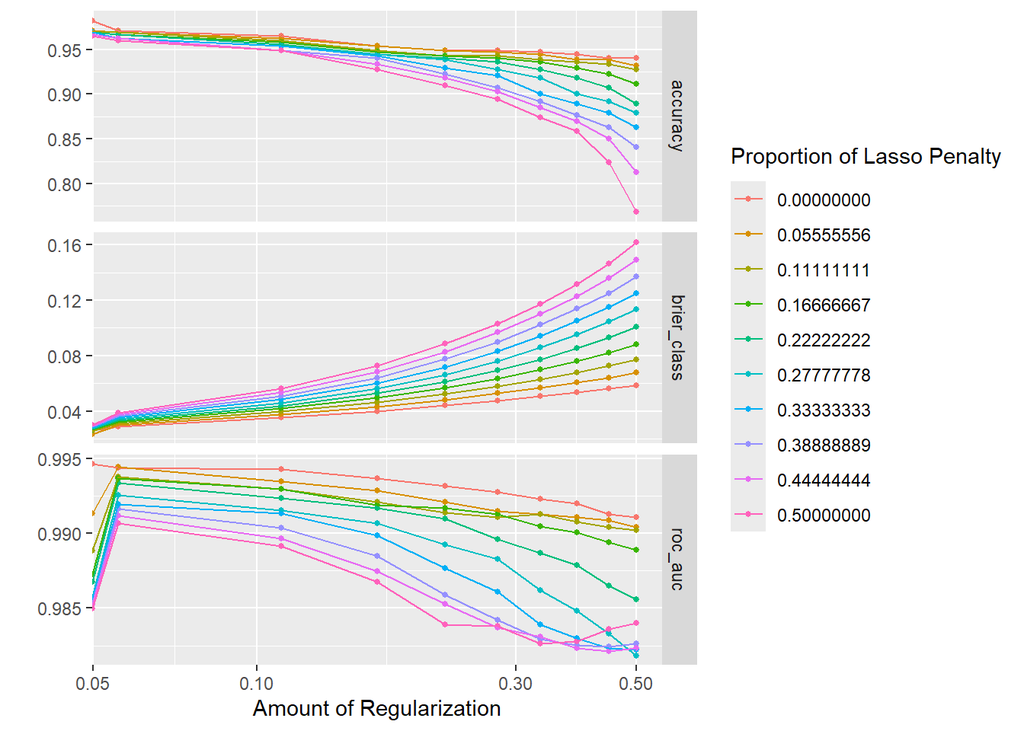

```r
autoplot(enet_tune_res)
```

```r
performance_metrics <- bind_rows(performance_metrics,
                                tibble(Model = "Elastic Net",
                                       AUC= as.double(show_best(enet_tune_res)[1,5])))
```

An elastic net is essentially a generalized version of logistic regression that has two hyperparameters, mixture and penalty. From the plots above we can see that the model that performed the best actually had both a penalty and a mixture value of 0. Thus this model is equivalent to a standard logistic regression. The ROC AUC for this model is 0.9946 which is even better than the KNN model!

### Random Forest

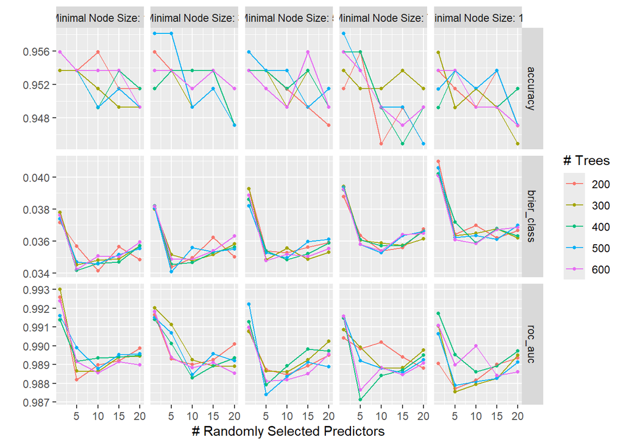

```r
autoplot(rf_tune)
```

```r
performance_metrics <- bind_rows(performance_metrics,
                                tibble(Model = "Random Forest",
                                       AUC= as.double(show_best(rf_tune)[1,6])))
```

The next model we fit is a random forest. Random forests are a collection of decision trees (flow chart-esque models) that output the mode class predicted from each decision tree that it is made of. It has three hyperparameters: m_try (the number of predictors to be considered at each split in a tree), min_n (the number of observations that must be in a node in order for another split to occur), and trees (the number of trees in the ensemble). The autoplots generated from a tuned random forest are generally really hard to read due to the sheer number of plots that they contain. However, a close inspection shows us that with low values of m_try, and min_n performed better with the best model having a min_n of 1, an m_try of 1 and 300 trees. This best model had an AUC of 0.9930 which is slightly worse than the AUC of the best elastic net model.

### Gradient Boosted Tree

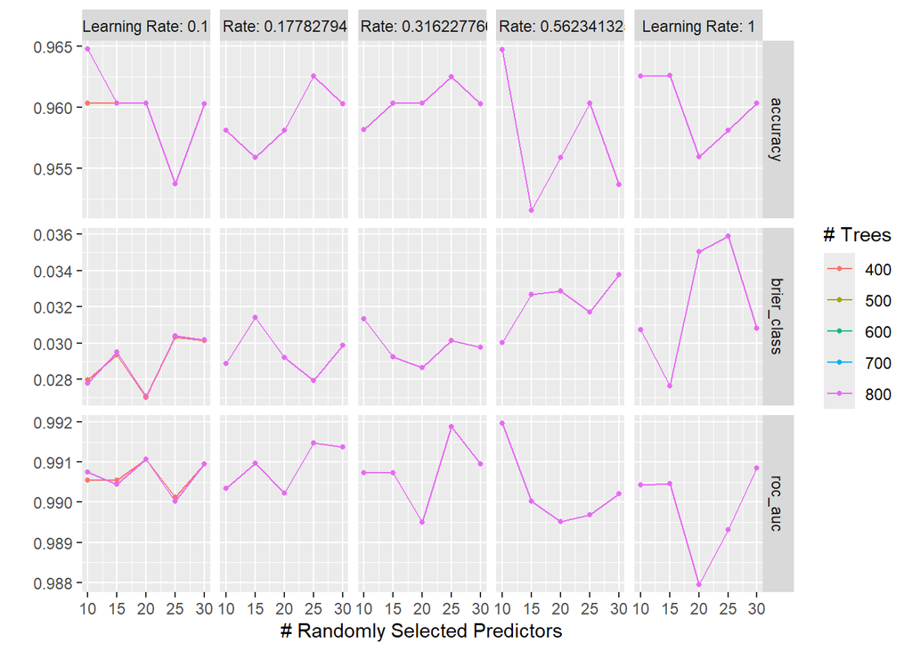

```r
autoplot(bt_tune)
```

```r
performance_metrics <- bind_rows(performance_metrics,
                                tibble(Model = "Boosted Tree",
                                       AUC = as.double(show_best(bt_tune)[1,6])))
```

Gradient boosted trees are a similar type of model to a random forest as they both are made up of a collection of decision trees. However, where the trees in a random forest are created independently from one another, the trees in a gradient boosted ensemble depend on, and try to fix the mistakes of the previous tree. Gradient boosted trees contain the following hyperparameters: m_try, trees, and learning rate (essentially a value that determines how much each tree should try to correct the mistakes of the previous tree). It is incredibly hard to discern any kind of pattern from the above graphs, but a look at the actual values tells us that the best performing model had a learning rate of 0.56, 400 trees, and an m_try of 10. This model had an AUC of 0.9920 putting ahead of the KNN model.

### SVM

[figure not shown]

```r
autoplot(svm_rbf_res)
```

```r
performance_metrics <- bind_rows(performance_metrics,
                                tibble(Model = "SVM",
                                       AUC= as.double(show_best(svm_rbf_res)[2,4])))
```

### Final Comparisons

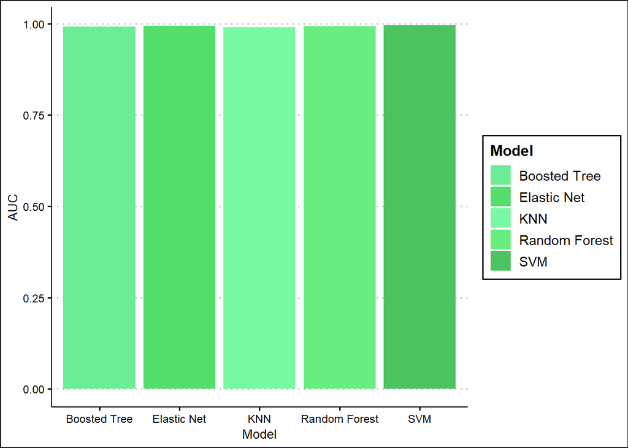

```r
performance_metrics %>%
ggplot(aes(x=Model, y=AUC)) +
geom_bar(stat = "identity", aes(fill=Model)) +
scale_fill_manual(values = c("#6CEC96","#55DE6C","#79F8A3", "#6AED80","#4CC360")) +
theme_clean()
```

Here we have a graph comparing how each model performed, with darker shades of green corresponding to better models. We have the following rankings of performance from best to worst:

1. SVM
2. Elastic Net
3. Random Forest
4. Boosted Trees
5. KNN

So the support vector machine with a cost of 1.35 ends up being our best model with an AUC of 0.99531!